# Practical Machine Learning: Project1

**Background:**  
Using devices such as Jawbone Up, Nike FuelBand, and Fitbit it is now possible to collect a large amount of data about personal activity relatively inexpensively. These type of devices are part of the quantified self movement - a group of enthusiasts who take measurements about themselves regularly to improve their health, to find patterns in their behavior, or because they are tech geeks. One thing that people regularly do is quantify how much of a particular activity they do, but they rarely quantify how well they do it. In this report, I will use data from accelerometers on the belt, forearm, arm, and dumbell of 6 participants. They were asked to perform barbell lifts correctly and incorrectly in 5 different ways. More information is available from this [website](http://groupware.les.inf.puc-rio.br/har).

**Summary:**  
The training data for my machine learning algorithm was taken from [here](https://d396qusza40orc.cloudfront.net/predmachlearn/pml-training.csv). The model I create using the training data set will be finally applied on the test data found [here](https://d396qusza40orc.cloudfront.net/predmachlearn/pml-testing.csv) to predict the manner in which they did the exercise. ‘classe’ variable is the expected outcome from the model.

*Data Processing:*  
1. First we load the data. Download the training and test data if necessary, and then load the data to trainData and testData.

```r
setwd("D://PracticalMachineLearning")
if (!file.exists("pml-training.csv")) {
  download.file("https://d396qusza40orc.cloudfront.net/predmachlearn/pml-training.csv", destfile="pml-training.csv")
  download.file("https://d396qusza40orc.cloudfront.net/predmachlearn/pml-testing.csv", destfile="pml-testing.csv")
}
trainData <- read.csv("pml-training.csv");testData <- read.csv("pml-testing.csv");
```

2. Clean data of unnecessary predictor variables. This is done in 3 steps. First step check for predictors with less than 60% missing values to be included. Second step eliminates nearZeroVar. Finally, we eliminate the columns related to timestamp, user or those columns in which the data is ordered. Since the user or ordered columns or timestamp may vary for test data, our model should not depend on those column so that it can predict with better accuracy. Split trainData into training/testing data sets for conducting the model fit and predictions that best explains the data.

```r
library(caret); set.seed(4321)
fn <- function(col1, data) {
    if ((length(data[is.na(data[,col1]),col1])/length(data[,col1])) < 0.6) {
        names(data)[col1]
    } else {""}
}
cols <- sapply(1:dim(trainData)[2],fn,trainData) #reduce features based on NA in testData
trainData <- trainData[, which(names(trainData) %in% cols)]
trainData <- trainData[, c(-1:-6)] # Drop the user, ordered and timestamp columns
nsv <- nearZeroVar(trainData, saveMetrics=TRUE); cols <- row.names(nsv)[nsv$nzv!=TRUE]
trainData <- trainData[, which(names(trainData) %in% cols)]
trainIndex = createDataPartition(trainData$classe, p=0.6,list=FALSE)
trainingData = trainData[trainIndex,]; testingData = trainData[-trainIndex,]
```

*Model1: Using rpart2 method*  
*Cross-validations:* For rpart2 method, number of folds / cross validation sets is set to 16.

3. Create model to fit the data, identifying the outcome and predictors and using ‘rpart2’ method to use.

```r
set.seed(33134); modelFit1 <- train(classe ~ ., data=trainingData, method="rpart2", trControl = trainControl(method="cv",number = 16));
```

4. Plot the model and glean any insights from the model data.

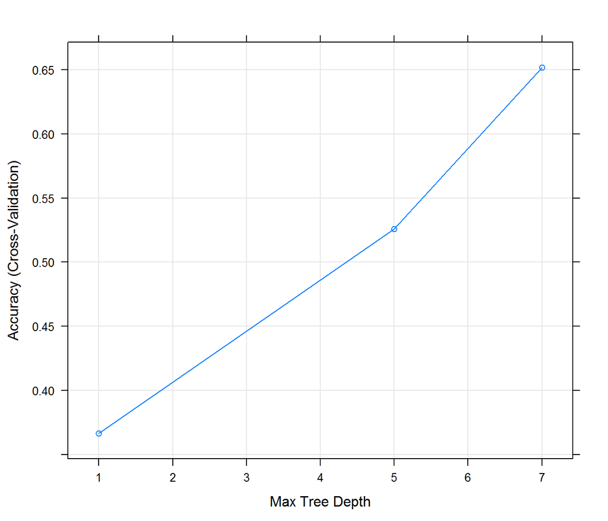

```r
plot(modelFit1);
```

From the plot of the ‘rpart2’ based model, we can see that the best accuracy using max tree depth of 7 is still 65%. This is not a pleasing modelFit and might be error prone about 35% of the time.

```r
pred1 <- predict(modelFit1, newdata=testingData)
matrix2 <- confusionMatrix(pred1, testingData$classe)
```

7. Create model to fit the data, identifying the outcome and predictors and using a random forest method to use.

```r
set.seed(33134); modelFit <- train(classe ~ ., data=trainingData, method="rf", prox=TRUE, trControl = trainControl(method="cv",number = 5));
print(modelFit)
```

```
## Random Forest
##
## 11776 samples
##    53 predictor
##     5 classes: 'A', 'B', 'C', 'D', 'E'
##
## No pre-processing
## Resampling: Cross-Validated (5 fold)
##
## Summary of sample sizes: 9422, 9420, 9422, 9420, 9420
##
## Resampling results across tuning parameters:
##
##   mtry  Accuracy  Kappa  Accuracy SD  Kappa SD
##    2    1         1      0.002        0.003
##   27    1         1      0.002        0.002
##   53    1         1      0.004        0.005
##
## Accuracy was used to select the optimal model using  the largest value.
## The final value used for the model was mtry = 27.
```

8. Plot the 4 most important predictors from the model and glean any insights from the model data.

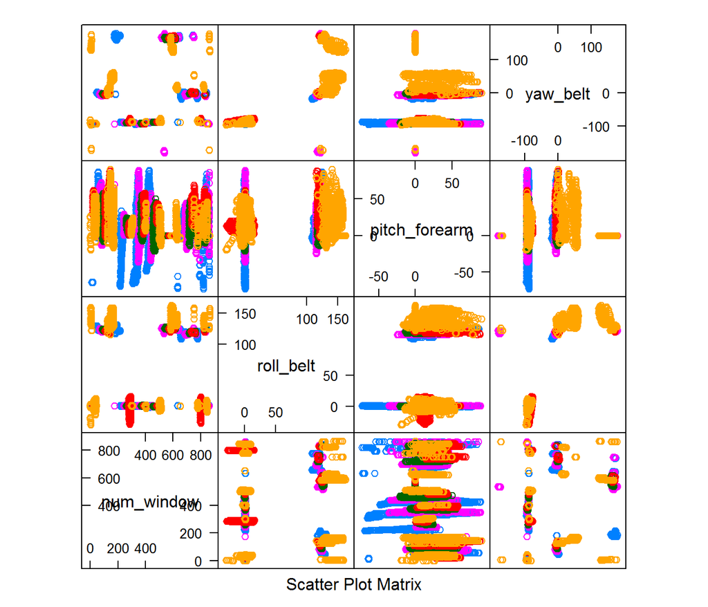

```r
library(caret)
#varImp(modelFit)
featurePlot (x=trainingData[,c("num_window","roll_belt","pitch_forearm",'yaw_belt')],y=trainingData$classe,plot="pairs")
```

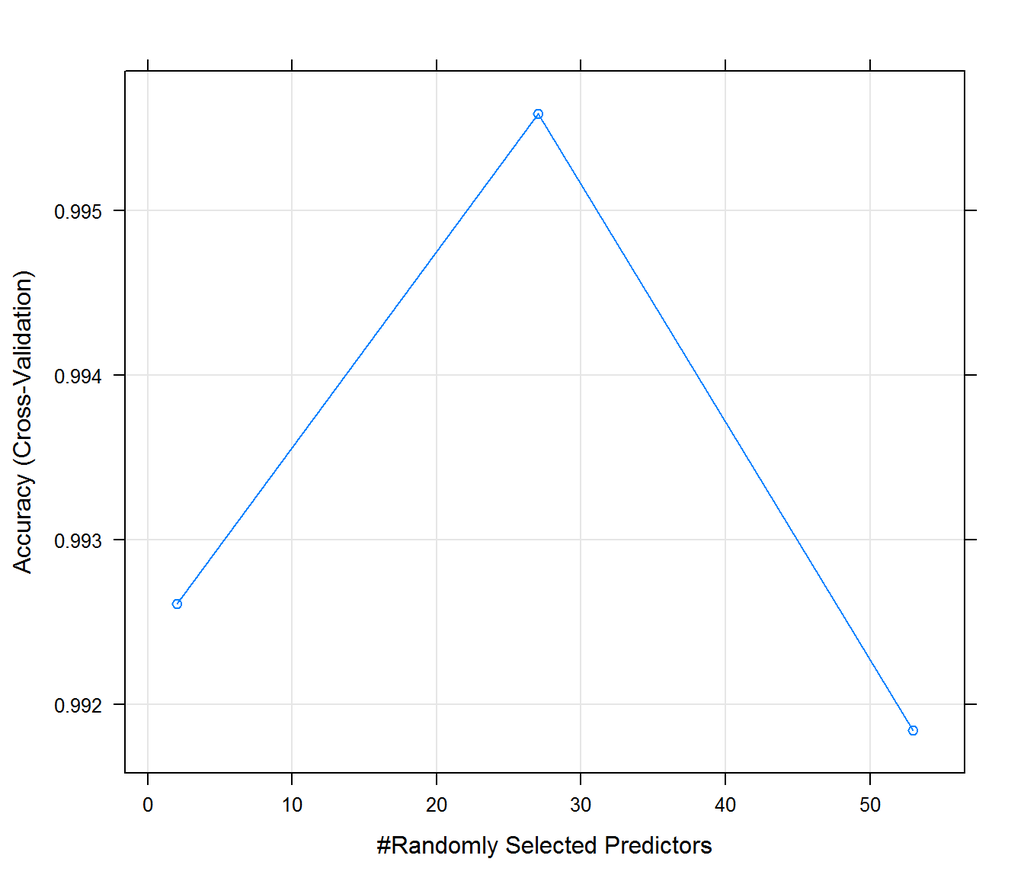

```r
plot(modelFit)
```

From the plot of the modelFit, we can see that the best accuracy obtained was around 99.6% which is very promising and would predict with less than 0.4% error rates. This is the best of the 2 modelFits and we would choose this randomForest based modelFit anytime, given a choice.

```r
print(modelFit$finalModel)
```

```
##
## Call:
##  randomForest(x = x, y = y, mtry = param$mtry, proximity = TRUE)
##                Type of random forest: classification
##                      Number of trees: 500
## No. of variables tried at each split: 27
##
##         OOB estimate of  error rate: 0.33%
## Confusion matrix:
##      A    B    C    D    E class.error
## A 3348    0    0    0    0    0.000000
## B    8 2265    6    0    0    0.006143
## C    0    7 2047    0    0    0.003408
## D    0    0   11 1919    0    0.005699
## E    0    1    0    6 2158    0.003233
```

With the second model using randomForest method, our expected out of sample error rate (incorrectly identified) is 0.33%. Our Accuracy (correctly identified) for the prediction is 99.67%.

9. Predict the values for testingData using the model created for fitting the training data and ompare the out of box sample error for the predicted values using the confusion matrix.

```r
pred <- predict(modelFit, newdata=testingData)
matrix1 <- confusionMatrix(pred, testingData$classe)
print(matrix1)
```

```
## Confusion Matrix and Statistics
##
##           Reference
## Prediction    A    B    C    D    E
##          A 2231    3    0    0    0
##          B    0 1512    1    0    0
##          C    0    3 1367    3    0
##          D    0    0    0 1283    2
##          E    1    0    0    0 1440
##
## Overall Statistics
##
##                Accuracy : 0.998
##                  95% CI : (0.997, 0.999)
##     No Information Rate : 0.284
##     P-Value [Acc > NIR] : <2e-16
##
##                   Kappa : 0.998
##  Mcnemar's Test P-Value : NA
##
## Statistics by Class:
##
##                      Class: A Class: B Class: C Class: D Class: E
## Sensitivity             1.000    0.996    0.999    0.998    0.999
## Specificity             0.999    1.000    0.999    1.000    1.000
## Pos Pred Value          0.999    0.999    0.996    0.998    0.999
## Neg Pred Value          1.000    0.999    1.000    1.000    1.000
## Prevalence              0.284    0.193    0.174    0.164    0.184
## Detection Rate          0.284    0.193    0.174    0.164    0.184
## Detection Prevalence    0.285    0.193    0.175    0.164    0.184
## Balanced Accuracy       1.000    0.998    0.999    0.999    0.999
```